# R Notebook

```r
library(tidyverse)
library(janitor)
```

I’m going to start by just getting all the graphs together in one space.

**Remember, before adding the map stuff, make sure to do an add, commit and push and maybe find a way to stop the html file being too huge**

**Slide 1**

No visual content

**Slide 2**

No visual content, although may need a screen shot of the type of dataframe. Also, could do some screenshots of some of the planning documents that were used could be useful

**Slide 3**

[Graph 1]

```r
graph_1_data <- read_csv("data/presentation_data/graph_1_all_means_scot_groups_less_11.csv") %>% clean_names()
```

```r
graph_1_data
```

| type | class | mean |
| --- | --- | --- |
| household_type | With Children | 89 |
| type_of_tenure | Owned Mortgage/Loan | 89 |
| age | 16-34 years | 88 |
| age | 35-64 years | 87 |
| ethnicity | White | 87 |
| gender | Male | 87 |
| household_type | Adults (non pension, no children) | 87 |
| simd_quintiles | 80% least deprived | 87 |
| urban_rural_classification | Rural | 87 |
| urban_rural_classification | Urban | 86 |

[output cut: 9 more lines]

```r
graph_1_data <-
graph_1_data %>%
  arrange(desc(type), desc(mean)) %>%
  mutate(class = factor(class, levels = class)) %>%
  mutate(class = recode(class, "Adults (non pension, no children)" = "Adults (-psn, -child)"))
```

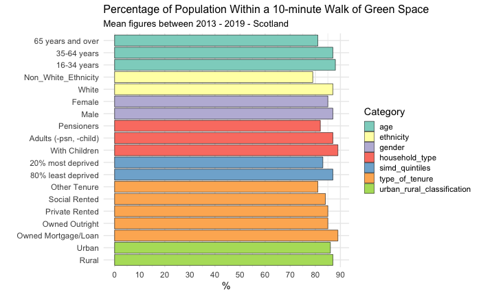

```r
# Need to work out how to separate types

graph_1_final <-
graph_1_data %>%
  ggplot() +
  aes(x = class, y = mean, fill = type) +
  geom_col(colour = "black", size = 0.2) +
  theme_minimal() +
  scale_y_continuous(breaks = seq(from = 0, to = 100, by = 10)) +
  coord_flip() +
  scale_fill_brewer(palette = "Set3") +
  labs(title = "Percentage of Population Within a 10-minute Walk of Green Space",
          subtitle = "Mean figures between 2013 - 2019 - Scotland") +
  xlab("") +
  ylab("%") +
  labs(fill = "Category") +
  theme(plot.title = element_text(size = 12.0),
        plot.subtitle = element_text(size = 10.0),
        legend.key.size = unit(0.4, "cm"),
        legend.key.width = unit(0.4, "cm"))

graph_1_final
```

1. It looks like there is a sustained gap between people with a mortgage and other types of tenure. This is quite curios, especially considering one of these alternative groups is owned outright. Equally, it appears that individuals who reported having an other form of tenure apart from those provided were less likely to have local access.
2. Although there is a gap between the two SIMD groups, this is perhaps not as large as I would have expected. 3. Pensioners seem to lag behind other household groups.
3. Males report closer access, but not by a large margin.
4. 65 year-olds and older seem to lag to a significant level behind other age groups.
5. Perhaps most strikingly of all, those of White ethnicity are far more likely to report having local access to green space when compared to all other individuals of Non-White Ethnicity.

**Slide 4**

```r
graph_2_data <- read_csv("data/presentation_data/graph_2_minus_5_all_means_scot_groups.csv") %>% clean_names()
```

```r
graph_2_data <-
graph_2_data %>%
  arrange(desc(type), desc(mean)) %>%
  mutate(class = factor(class, levels = class)) %>%
  mutate(class = recode(class, "Adults (non pension, no children)" = "Adults (-psn, -child)"))
```

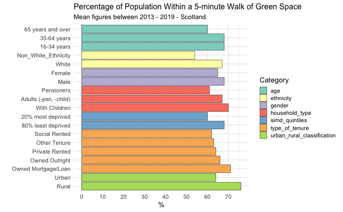

```r
graph_2_final <-
graph_2_data %>%
  ggplot() +
  aes(x = class, y = mean, fill = type) +
  geom_col(colour = "black", size = 0.2) +
  theme_minimal() +
  scale_y_continuous(breaks = seq(from = 0, to = 100, by = 10)) +
  coord_flip() +
  scale_fill_brewer(palette = "Set3") +
  labs(title = "Percentage of Population Within a 5-minute Walk of Green Space",
          subtitle = "Mean figures between 2013 - 2019 - Scotland") +
  xlab("") +
  ylab("%") +
  labs(fill = "Category") +
  theme(plot.title = element_text(size = 12.0),
        plot.subtitle = element_text(size = 10.0),
        legend.key.size = unit(0.4, "cm"),
        legend.key.width = unit(0.4, "cm"))


  graph_2_final
```

**This is the stage to pick out some of our headline changes**

We can do this with the below:

1. The gap between those who have a mortgage/other domestic loan and other tenure groups has been maintained. Interestingly, the Social Renting group has dropped below the group Other Tenure. The percentage point gap between mortgage and social renting group was 9 points.
2. The gap between the two SIMD groups has widened significantly. In the 10 or less analysis, it was 4 percentage points. In 5 or less, it is 8 points.
3. Pensioners once again lagged behind adults with and without children.
4. Males once again report closer access, with the margin growing only slightly from 2 percentage points to 3.
5. The gap between 65-year-olds+ was maintained.
6. Once again, the headline figure is that the gap in local access between white and non-white ethnicity has been further widened with a gap of 13 percentage points, up from 8. Those classed as non-white ethnicity had the lowest percentage of any group addressed over the last 7 years period looked into, with only 54% having access to green or blue space within 5 minutes walk of there house. **This should be put into context by highlighting the definition again**.

**Rather than do any more data wrangling, we can also just show the plus minus figures for certain gaps in categories.**

```r
graph_1_data
```

| type | class | mean |
| --- | --- | --- |
| urban_rural_classification | Rural | 87 |
| urban_rural_classification | Urban | 86 |
| type_of_tenure | Owned Mortgage/Loan | 89 |
| type_of_tenure | Owned Outright | 85 |
| type_of_tenure | Private Rented | 85 |
| type_of_tenure | Social Rented | 84 |
| type_of_tenure | Other Tenure | 81 |
| simd_quintiles | 80% least deprived | 87 |
| simd_quintiles | 20% most deprived | 83 |
| household_type | With Children | 89 |

[output cut: 9 more lines]

```r
graph_2_data
```

| type | class | mean |
| --- | --- | --- |
| urban_rural_classification | Rural | 76 |
| urban_rural_classification | Urban | 64 |
| type_of_tenure | Owned Mortgage/Loan | 71 |
| type_of_tenure | Owned Outright | 66 |
| type_of_tenure | Private Rented | 64 |
| type_of_tenure | Other Tenure | 63 |
| type_of_tenure | Social Rented | 62 |
| simd_quintiles | 80% least deprived | 68 |
| simd_quintiles | 20% most deprived | 60 |
| household_type | With Children | 70 |

[output cut: 9 more lines]

Infographics saved on flaticon website

**Slide 5**

```r
graph_6_data <- read_csv("data/presentation_data/graph_3_4_5_final_scot_13_19_sig_less_5.csv") %>% clean_names
graph_3_all_scot_n5s <-read_csv("data/presentation_data/graph_3_final_scot_all_years_sig_less_5.csv")
```

Start with ethnicity

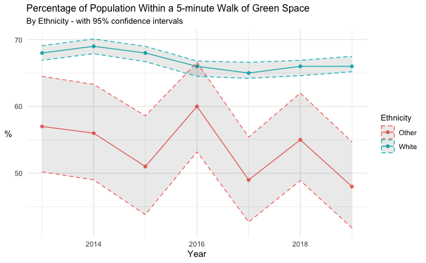

```r
ethnicity_graph_3 <-
graph_3_all_scot_n5s %>%
  filter(type == "ethnicity")


ethinicity_plot <-
  ethnicity_graph_3 %>%
  ggplot() +
  aes(x = date_code, y = percent, colour = class) +
  geom_point() +
  geom_line() +
  theme_minimal()


ethnicity_plot_n5s <-
  ethinicity_plot +
  geom_ribbon(aes(ymin = ethnicity_graph_3$x95_percent_lower_confidence_limit_percent, ymax = ethnicity_graph_3$x95_percent_upper_confidence_limit_percent), linetype = 2, alpha = 0.1) +
  labs(title = "Percentage of Population Within a 5-minute Walk of Green Space",
          subtitle = "By Ethnicity - with 95% confidence intervals") +
  xlab("Year") +
  ylab("%") +
  labs(color = "Ethnicity") +
  theme(plot.title = element_text(size = 12.0),
        plot.subtitle = element_text(size = 10.0),
        axis.title.y = element_text(angle = 0, vjust = 0.5),
        legend.title = element_text(size = 10.0)
  )



graph_3_final_ethnicity_plot_n5s <-
  ethnicity_plot_n5s

graph_3_final_ethnicity_plot_n5s
```

Now for tenure:

```r
graph_3_all_scot_n5s %>%
  distinct(type)
```

| type |
| --- |
| household_type |
| simd_quintiles |
| age |
| type_of_tenure |
| gender |
| urban_rural_classification |
| ethnicity |
| All |

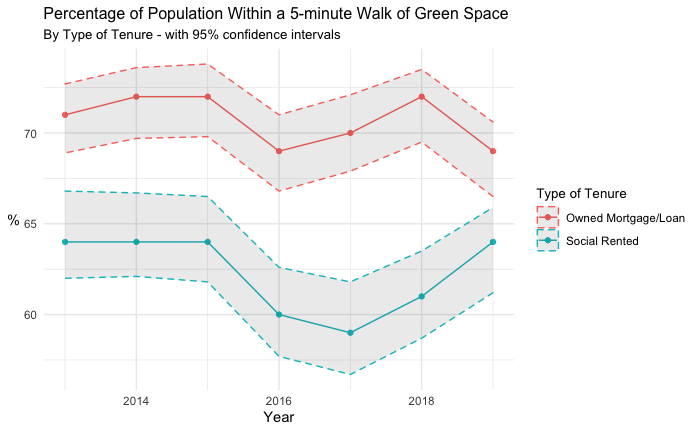

```r
tenure_graph_4 <-
graph_3_all_scot_n5s %>%
  filter(type == "type_of_tenure",
         class %in% c("Owned Mortgage/Loan", "Social Rented"))


tenure_plot <-
  tenure_graph_4 %>%
  ggplot() +
  aes(x = date_code, y = percent, colour = class) +
  geom_point() +
  geom_line() +
  theme_minimal()


tenure_plot_n5s <-
  tenure_plot +
  geom_ribbon(aes(ymin = tenure_graph_4$x95_percent_lower_confidence_limit_percent, ymax = tenure_graph_4$x95_percent_upper_confidence_limit_percent), linetype = 2, alpha = 0.1) +
  labs(title = "Percentage of Population Within a 5-minute Walk of Green Space",
          subtitle = "By Type of Tenure - with 95% confidence intervals") +
  xlab("Year") +
  ylab("%") +
  labs(color = "Type of Tenure") +
  theme(plot.title = element_text(size = 12.0),
        plot.subtitle = element_text(size = 10.0),
        axis.title.y = element_text(angle = 0, vjust = 0.5),
        legend.title = element_text(size = 10.0)
  )



graph_4_final_tenure_plot_n5s <-
  tenure_plot_n5s

graph_4_final_tenure_plot_n5s
```

And by Scottish Index of Multiple Definition groupings:

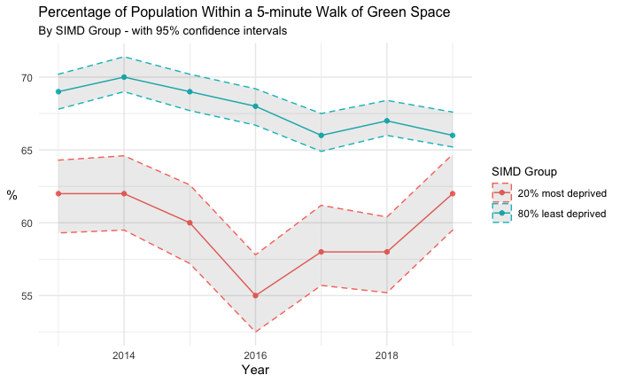

```r
simd_graph_5 <-
graph_3_all_scot_n5s %>%
  filter(type == "simd_quintiles")


simd_plot <-
  simd_graph_5 %>%
  ggplot() +
  aes(x = date_code, y = percent, colour = class) +
  geom_point() +
  geom_line() +
  theme_minimal()


simd_plot_n5s <-
  simd_plot +
  geom_ribbon(aes(ymin = simd_graph_5$x95_percent_lower_confidence_limit_percent, ymax = simd_graph_5$x95_percent_upper_confidence_limit_percent), linetype = 2, alpha = 0.1) +
  labs(title = "Percentage of Population Within a 5-minute Walk of Green Space",
          subtitle = "By SIMD Group - with 95% confidence intervals") +
  xlab("Year") +
  ylab("%") +
  labs(color = "SIMD Group") +
  theme(plot.title = element_text(size = 12.0),
        plot.subtitle = element_text(size = 10.0),
        axis.title.y = element_text(angle = 0, vjust = 0.5),
        legend.title = element_text(size = 10.0)
  )



graph_5_final_simd_plot_n5s <-
  simd_plot_n5s

graph_5_final_simd_plot_n5s
```

**Slide 6**

```r
graph_6_data
```

| feature_code | units | distance_to_nearest_green_or_blue_space | x95_percent_upper_confidence_limit_percent_2013 | x95_percent_upper_confidence_limit_percent_2019 | percent_2013 | percent_2019 | x95_percent_lower_confidence_limit_percent_2013 | x95_percent_lower_confidence_limit_percent_2019 | upper_interval_2013 | upper_interval_2019 | lower_interval_2013 | lower_interval_2019 | combined_interval_2013 | combined_interval_2019 | signif_1 | signif_2 | signif_3 | type | class | sign_change_13_to_19 |
| --- | --- | --- | --- | --- | --- | --- | --- | --- | --- | --- | --- | --- | --- | --- | --- | --- | --- | --- | --- | --- |
| S92000003 | Percent Of Adults | A 5 minute walk or less | 72.0 | 69.8 | 70 | 68 | 67.6 | 65.4 | 2.0 | 1.8 | 2.4 | 2.6 | 4.4 | 4.4 | FALSE | FALSE | FALSE | household_type | With Children | FALSE |
| S92000003 | Percent Of Adults | A 5 minute walk or less | 63.7 | 61.7 | 62 | 60 | 60.1 | 58.0 | 1.7 | 1.7 | 1.9 | 2.0 | 3.6 | 3.7 | FALSE | TRUE | FALSE | household_type | Pensioners | TRUE |
| S92000003 | Percent Of Adults | A 5 minute walk or less | 71.2 | 68.8 | 69 | 67 | 67.8 | 65.5 | 2.2 | 1.8 | 1.2 | 1.5 | 3.4 | 3.3 | FALSE | TRUE | FALSE | household_type | Adults | TRUE |
| S92000003 | Percent Of Adults | A 5 minute walk or less | 64.3 | 64.7 | 62 | 62 | 59.3 | 59.5 | 2.3 | 2.7 | 2.7 | 2.5 | 5.0 | 5.2 | FALSE | FALSE | FALSE | simd_quintiles | 20% most deprived | FALSE |
| S92000003 | Percent Of Adults | A 5 minute walk or less | 70.2 | 67.6 | 69 | 66 | 67.8 | 65.2 | 1.2 | 1.6 | 1.2 | 0.8 | 2.4 | 2.4 | TRUE | TRUE | TRUE | simd_quintiles | 80% least deprived | TRUE |
| S92000003 | Percent Of Adults | A 5 minute walk or less | 62.5 | 61.3 | 60 | 59 | 58.4 | 57.5 | 2.5 | 2.3 | 1.6 | 1.5 | 4.1 | 3.8 | FALSE | FALSE | FALSE | age | 65 years and over | FALSE |
| S92000003 | Percent Of Adults | A 5 minute walk or less | 69.9 | 68.8 | 68 | 67 | 66.9 | 65.6 | 1.9 | 1.8 | 1.1 | 1.4 | 3.0 | 3.2 | FALSE | FALSE | FALSE | age | 35-64 years | FALSE |
| S92000003 | Percent Of Adults | A 5 minute walk or less | 73.6 | 70.0 | 71 | 68 | 69.0 | 65.3 | 2.6 | 2.0 | 2.0 | 2.7 | 4.6 | 4.7 | FALSE | TRUE | FALSE | age | 16-34 years | TRUE |
| S92000003 | Percent Of Adults | A 5 minute walk or less | 72.7 | 70.6 | 71 | 69 | 68.9 | 66.5 | 1.7 | 1.6 | 2.1 | 2.5 | 3.8 | 4.1 | FALSE | FALSE | FALSE | type_of_tenure | Owned Mortgage/Loan | FALSE |
| S92000003 | Percent Of Adults | A 5 minute walk or less | 68.9 | 71.6 | 60 | 60 | 50.9 | 48.9 | 8.9 | 11.6 | 9.1 | 11.1 | 18.0 | 22.7 | FALSE | FALSE | FALSE | type_of_tenure | Other | FALSE |

[output cut: 10 more lines]

```r
graph_6_select <-
graph_6_data %>%
  mutate(class = if_else((type == "ethnicity") &
                           (class == "Other"),
                         "Non_White_Ethnicity", class)) %>%
  mutate(class = if_else((type == "type_of_tenure") &
                           (class == "Other"),
                         "Other Tenure", class)) %>%
  select(-c(units, x95_percent_upper_confidence_limit_percent_2013: x95_percent_upper_confidence_limit_percent_2019, x95_percent_lower_confidence_limit_percent_2013:signif_3))


graph_6_pivot <-
graph_6_select %>%
pivot_longer(cols = percent_2013:percent_2019, names_to = "year", values_to = "percent") %>%
  mutate(year = str_remove(year, "percent_"))

graph_6_pivot
```

| feature_code | distance_to_nearest_green_or_blue_space | type | class | sign_change_13_to_19 | year | percent |
| --- | --- | --- | --- | --- | --- | --- |
| S92000003 | A 5 minute walk or less | household_type | With Children | FALSE | 2013 | 70 |
| S92000003 | A 5 minute walk or less | household_type | With Children | FALSE | 2019 | 68 |
| S92000003 | A 5 minute walk or less | household_type | Pensioners | TRUE | 2013 | 62 |
| S92000003 | A 5 minute walk or less | household_type | Pensioners | TRUE | 2019 | 60 |
| S92000003 | A 5 minute walk or less | household_type | Adults | TRUE | 2013 | 69 |
| S92000003 | A 5 minute walk or less | household_type | Adults | TRUE | 2019 | 67 |
| S92000003 | A 5 minute walk or less | simd_quintiles | 20% most deprived | FALSE | 2013 | 62 |
| S92000003 | A 5 minute walk or less | simd_quintiles | 20% most deprived | FALSE | 2019 | 62 |
| S92000003 | A 5 minute walk or less | simd_quintiles | 80% least deprived | TRUE | 2013 | 69 |
| S92000003 | A 5 minute walk or less | simd_quintiles | 80% least deprived | TRUE | 2019 | 66 |

[output cut: 30 more lines]

```r
graph_6_pivot_test <-
  graph_6_pivot %>%
  arrange(desc(type)) %>%
  mutate(class = factor(class, levels = unique(class), order = TRUE)) %>%
  mutate(year = factor(year, levels = unique(year), order = TRUE))

graph_6_pivot_test
```

| feature_code | distance_to_nearest_green_or_blue_space | type | class | sign_change_13_to_19 | year | percent |
| --- | --- | --- | --- | --- | --- | --- |
| S92000003 | A 5 minute walk or less | urban_rural_classification | Urban | TRUE | 2013 | 66 |
| S92000003 | A 5 minute walk or less | urban_rural_classification | Urban | TRUE | 2019 | 64 |
| S92000003 | A 5 minute walk or less | urban_rural_classification | Rural | FALSE | 2013 | 75 |
| S92000003 | A 5 minute walk or less | urban_rural_classification | Rural | FALSE | 2019 | 73 |
| S92000003 | A 5 minute walk or less | type_of_tenure | Owned Mortgage/Loan | FALSE | 2013 | 71 |
| S92000003 | A 5 minute walk or less | type_of_tenure | Owned Mortgage/Loan | FALSE | 2019 | 69 |
| S92000003 | A 5 minute walk or less | type_of_tenure | Other Tenure | FALSE | 2013 | 60 |
| S92000003 | A 5 minute walk or less | type_of_tenure | Other Tenure | FALSE | 2019 | 60 |
| S92000003 | A 5 minute walk or less | type_of_tenure | Owned Outright | TRUE | 2013 | 67 |
| S92000003 | A 5 minute walk or less | type_of_tenure | Owned Outright | TRUE | 2019 | 64 |

[output cut: 30 more lines]

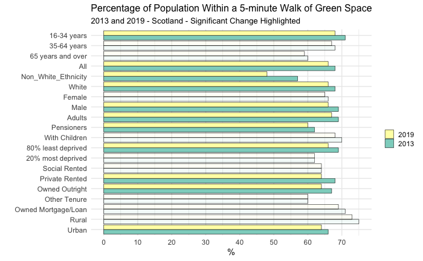

```r
#Need to switch years!!!.

graph_6_final <-
graph_6_pivot_test %>%
  ggplot() +
  aes(x = class, y = percent, fill = year) +
  geom_col(alpha = if_else(graph_6_pivot_test$sign_change_13_to_19 == TRUE, 1, 0.1),  colour = "black", size = 0.2, position = "dodge") +
  theme_minimal() +
  scale_y_continuous(breaks = seq(from = 0, to = 100, by = 10)) +
  coord_flip() +
  scale_fill_brewer(palette = "Set3") +
  labs(title = "Percentage of Population Within a 5-minute Walk of Green Space",
          subtitle = "2013 and 2019 - Scotland - Significant Change Highlighted") +
  xlab("") +
  ylab("%") +
  labs(fill = "") +
  guides(fill = guide_legend(reverse = TRUE)) +
  theme(plot.title = element_text(size = 12.0),
        plot.subtitle = element_text(size = 10.0),
        legend.key.size = unit(0.4, "cm"),
        legend.key.width = unit(0.4, "cm"))


  graph_6_final
```

**Slide 7**

[Graph 7] - maybe just try and use the other datasets or, worse comes to worse, the original gb_data_set

**LEAVING SLIDE 7 AND Q3 FOR NOW. IF WE REALLY WANT THIS, WE CAN ADD IT RIGHT IN AT THE END**

**Slide 8**

**I think this would be best just to do in the other notepad. I really don’t want to end up screwing up my git pushes with a massive file.

Can still do some of the intro charts though.

graph_3_all_scot_n5s

```r
graph_3_all_scot_n5s %>%
  distinct(type)
```

| type |
| --- |
| household_type |
| simd_quintiles |
| age |
| type_of_tenure |
| gender |
| urban_rural_classification |
| ethnicity |
| All |

```r
NA
```

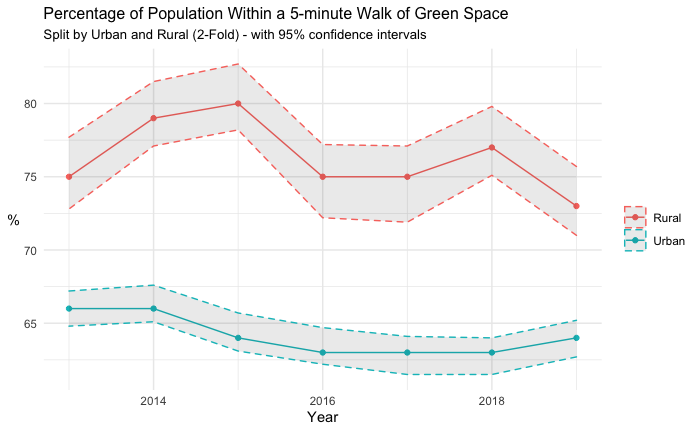

```r
urban_rural_extra_graph <-
graph_3_all_scot_n5s %>%
  filter(type == "urban_rural_classification")


urban_rural_extra_plot <-
  urban_rural_extra_graph %>%
  ggplot() +
  aes(x = date_code, y = percent, colour = class) +
  geom_point() +
  geom_line() +
  theme_minimal()


urban_rural_extra_plo_n5s <-
  urban_rural_extra_plot +
  geom_ribbon(aes(ymin = urban_rural_extra_graph$x95_percent_lower_confidence_limit_percent, ymax = urban_rural_extra_graph$x95_percent_upper_confidence_limit_percent), linetype = 2, alpha = 0.1) +
  labs(title = "Percentage of Population Within a 5-minute Walk of Green Space",
          subtitle = "Split by Urban and Rural (2-Fold) - with 95% confidence intervals") +
  xlab("Year") +
  ylab("%") +
  labs(color = "") +
  theme(plot.title = element_text(size = 12.0),
        plot.subtitle = element_text(size = 10.0),
        axis.title.y = element_text(angle = 0, vjust = 0.5),
        legend.title = element_text(size = 10.0)
  )



graph_8_final <- urban_rural_extra_plo_n5s

graph_8_final
```

```r
graph_9_data <- read_csv("data/presentation_data/graph_8a_local_means_plus_minus_scot.csv") %>% clean_names()
```

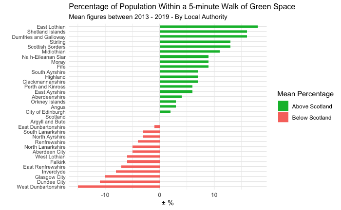

```r
graph_9_data <-
 graph_9_data %>%
  mutate(local_authority = fct_reorder(local_authority, pl_min_less_6))

graph_9_plot <-
graph_9_data %>%
  ggplot(aes(x = local_authority, y = pl_min_less_6, label = local_authority)) +
  geom_bar(stat = 'identity', aes(fill = above_below_less_6), width = .5) +
  scale_fill_manual(name = "Mean Percentage",
                    labels = c("Above Scotland", "Below Scotland"),
                    values = c("above" = "#00ba38", "below"= "#f8766d")) +
  theme_minimal() +
  labs(title = "Percentage of Population Within a 5-minute Walk of Green Space",
          subtitle = "Mean figures between 2013 - 2019 - By Local Authority") +
  coord_flip() +
  xlab("") +
  ylab("± %") +
  theme(axis.text.y = element_text(size = 8),
        plot.title = element_text(size = 12),
        plot.subtitle = element_text(size = 10))

graph_9_plot
```

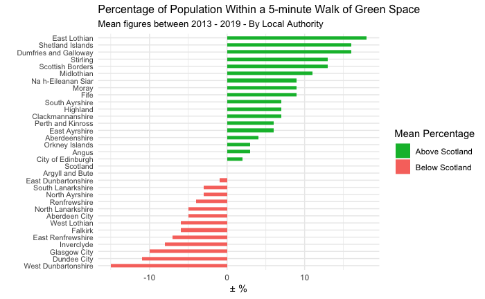

```r
graph_9a_by_local_authority_final <- graph_9_plot

graph_9a_by_local_authority_final
```

```r
graph_9_b_electoral_regions_data <- read_csv("data/presentation_data/graph_8b_label_above_below_with_electoral_regions.csv") %>% clean_names()
```

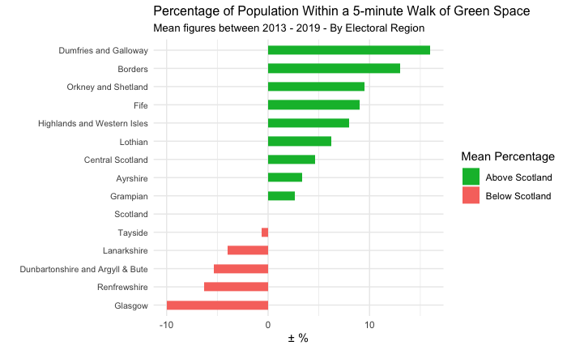

```r
graph_9_b_electoral_regions_data <-
  graph_9_b_electoral_regions_data %>%
  mutate(electoral_region = fct_reorder(electoral_region, mean_above_below),
         above_below_less_6 = if_else(mean_above_below < 0, "below", "above"))

  graph_9_b_electoral_regions_final <-
  graph_9_b_electoral_regions_data %>%
  ggplot(aes(x = electoral_region, y = mean_above_below, label = electoral_region)) +
  geom_bar(stat = 'identity', aes(fill = above_below_less_6), width = .5) +
  scale_fill_manual(name = "Mean Percentage",
                    labels = c("Above Scotland", "Below Scotland"),
                    values = c("above" = "#00ba38", "below"= "#f8766d")) +
  theme_minimal() +
  labs(title = "Percentage of Population Within a 5-minute Walk of Green Space",
          subtitle = "Mean figures between 2013 - 2019 - By Electoral Region") +
  coord_flip() +
  xlab("") +
  ylab("± %") +
  theme(axis.text.y = element_text(size = 8),
        plot.title = element_text(size = 12),
        plot.subtitle = element_text(size = 10))

  graph_9_b_electoral_regions_final
```

**Maps Done!!** Just a few more graphs to go now.

**Slide 9**

```r
graph_10_data <- read_csv("data/presentation_data/graph_9_regions_distances_pivot_long.csv") %>% clean_names
```

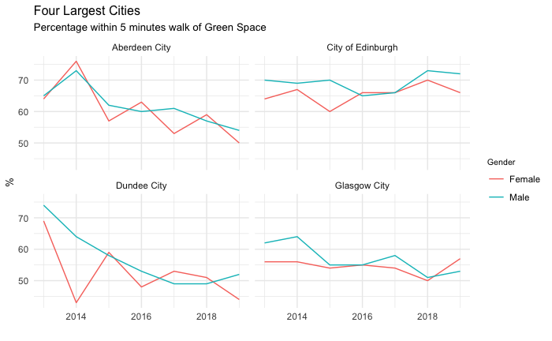

```r
graph_10_final <-
graph_10_data %>%
  filter(local_authority %in% c("Dundee City", "Aberdeen City", "City of Edinburgh", "Glasgow City"),
         type == "gender",
         walking_distance == "a_5_minute_walk_or_less") %>%
  ggplot(aes(x = year, y = values, colour = class)) +
  geom_line() +
  theme_minimal() +
  facet_wrap(~local_authority) +
  labs(title = "Four Largest Cities",
          subtitle = "Percentage within 5 minutes walk of Green Space") +
  xlab("") +
  ylab("%") +
  labs(colour = "Gender") +
  theme(axis.title.y = element_text(size = 10),
        plot.title = element_text(size = 12),
        plot.subtitle = element_text(size = 10),
        legend.title = element_text(size = 8))

graph_10_final
```

```r
remaining_graphs_data <- read_csv("data/presentation_data/graph_10_11_just_walking_distance_neigh_comm.csv") %>% clean_names()
```

```r
remaining_graphs_data
```

| date_code | gender | urban_rural_classification | simd_quintiles | type_of_tenure | household_type | ethnicity | walking_distance_to_nearest_greenspace | local_authority | nr_very_good | nr_no_opinion | nr_fairly_good | nr_very_poor | nr_fairly_poor | com_bel_very_strongly | com_bel_dont_know | com_bel_not_at_all_strongly | com_bel_fairly_strongly | com_bel_not_very_strongly |
| --- | --- | --- | --- | --- | --- | --- | --- | --- | --- | --- | --- | --- | --- | --- | --- | --- | --- | --- |
| 2013 | All | All | All | All | All | All | More than 10 minutes | North Lanarkshire | 40 | NA | 45 | 4 | 11 | 28 | 1 | 13 | 36 | 21 |
| 2018 | All | All | All | All | All | All | More than 10 minutes | South Lanarkshire | 54 | NA | 36 | 8 | 2 | 43 | NA | 9 | 31 | 16 |
| 2017 | All | All | All | All | All | All | More than 10 minutes | Aberdeen City | 54 | 2 | 42 | 1 | 1 | 31 | 2 | 12 | 35 | 21 |
| 2018 | All | All | All | All | All | All | More than 10 minutes | Aberdeen City | 48 | NA | 38 | 5 | 8 | 24 | 3 | 5 | 45 | 23 |
| 2019 | All | All | All | All | All | All | More than 10 minutes | North Lanarkshire | 42 | NA | 47 | 1 | 10 | 36 | NA | 10 | 39 | 15 |
| 2018 | All | All | All | All | All | All | More than 10 minutes | Orkney Islands | 81 | NA | 19 | NA | NA | 58 | NA | NA | 36 | 6 |
| 2016 | All | All | All | All | All | All | More than 10 minutes | Aberdeenshire | 65 | NA | 32 | NA | 4 | 39 | 1 | 7 | 38 | 15 |
| 2013 | All | All | All | All | All | All | More than 10 minutes | South Lanarkshire | 47 | NA | 45 | 4 | 5 | 42 | NA | 4 | 38 | 16 |
| 2014 | All | All | All | All | All | All | More than 10 minutes | Glasgow City | 42 | 0 | 51 | 3 | 4 | 40 | 0 | 5 | 42 | 12 |
| 2019 | All | All | All | All | All | All | More than 10 minutes | Glasgow City | 38 | 1 | 54 | 3 | 4 | 31 | 3 | 9 | 36 | 20 |

[output cut: 290 more lines]

```r
neigh_comm_extra_graph_data <-
remaining_graphs_data %>%
    filter(walking_distance_to_nearest_greenspace != "Don't Know",
         local_authority == "Scotland",
         gender == "All",
         urban_rural_classification == "All",
         simd_quintiles == "All",
         type_of_tenure == "All",
         household_type == "All",
         ethnicity == "All")

neigh_comm_extra_graph_data
```

| date_code | gender | urban_rural_classification | simd_quintiles | type_of_tenure | household_type | ethnicity | walking_distance_to_nearest_greenspace | local_authority | nr_very_good | nr_no_opinion | nr_fairly_good | nr_very_poor | nr_fairly_poor | com_bel_very_strongly | com_bel_dont_know | com_bel_not_at_all_strongly | com_bel_fairly_strongly | com_bel_not_very_strongly |
| --- | --- | --- | --- | --- | --- | --- | --- | --- | --- | --- | --- | --- | --- | --- | --- | --- | --- | --- |
| 2016 | All | All | All | All | All | All | More than 10 minutes | Scotland | 55 | 0 | 38 | 2 | 6 | 35 | 1 | 8 | 40 | 17 |
| 2017 | All | All | All | All | All | All | More than 10 minutes | Scotland | 52 | 0 | 41 | 1 | 5 | 33 | 2 | 7 | 42 | 16 |
| 2014 | All | All | All | All | All | All | More than 10 minutes | Scotland | 53 | 0 | 39 | 3 | 4 | 35 | 0 | 7 | 43 | 15 |
| 2019 | All | All | All | All | All | All | More than 10 minutes | Scotland | 54 | 0 | 38 | 2 | 6 | 33 | 1 | 7 | 39 | 20 |
| 2013 | All | All | All | All | All | All | More than 10 minutes | Scotland | 50 | 0 | 41 | 3 | 5 | 36 | 1 | 7 | 36 | 21 |
| 2014 | All | All | All | All | All | All | Less than 10 minutes | Scotland | 56 | 0 | 38 | 1 | 3 | 36 | 1 | 5 | 41 | 16 |
| 2015 | All | All | All | All | All | All | Less than 10 minutes | Scotland | 57 | 0 | 37 | 1 | 4 | 34 | 1 | 5 | 44 | 16 |
| 2019 | All | All | All | All | All | All | Less than 10 minutes | Scotland | 58 | 0 | 37 | 1 | 4 | 35 | 1 | 5 | 44 | 15 |
| 2018 | All | All | All | All | All | All | More than 10 minutes | Scotland | 53 | 0 | 38 | 2 | 6 | 36 | 1 | 6 | 38 | 18 |
| 2017 | All | All | All | All | All | All | Less than 10 minutes | Scotland | 58 | 0 | 37 | 1 | 3 | 35 | 1 | 5 | 44 | 15 |

[output cut: 4 more lines]

```r
neigh_extra_pivot <-
neigh_comm_extra_graph_data %>%
  select(-c(gender:ethnicity, local_authority, com_bel_very_strongly:com_bel_not_very_strongly)) %>%
  pivot_longer(cols = nr_very_good:nr_fairly_poor, names_to = "neighbourhood_rating", values_to = "nr_percent")
#  pivot_longer(cols = com_bel_very_strongly:com_bel_not_very_strongly, names_to = #"community_belonging_rating", values_to = "cb_percent")

neigh_extra_pivot
```

| date_code | walking_distance_to_nearest_greenspace | neighbourhood_rating | nr_percent |
| --- | --- | --- | --- |
| 2016 | More than 10 minutes | nr_very_good | 55 |
| 2016 | More than 10 minutes | nr_no_opinion | 0 |
| 2016 | More than 10 minutes | nr_fairly_good | 38 |
| 2016 | More than 10 minutes | nr_very_poor | 2 |
| 2016 | More than 10 minutes | nr_fairly_poor | 6 |
| 2017 | More than 10 minutes | nr_very_good | 52 |
| 2017 | More than 10 minutes | nr_no_opinion | 0 |
| 2017 | More than 10 minutes | nr_fairly_good | 41 |
| 2017 | More than 10 minutes | nr_very_poor | 1 |
| 2017 | More than 10 minutes | nr_fairly_poor | 5 |

[output cut: 60 more lines]

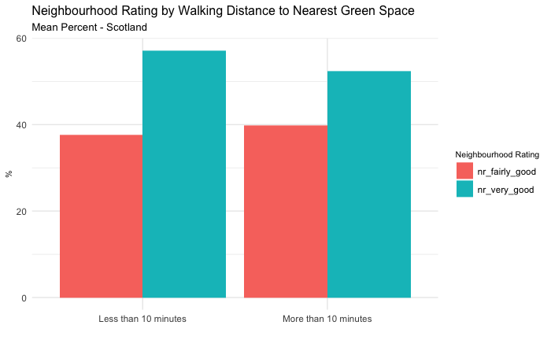

```r
neigh_extra_pivot_means <-
neigh_extra_pivot %>%
  group_by(walking_distance_to_nearest_greenspace, neighbourhood_rating) %>%
  summarise(mean(nr_percent)) %>%
  rename(mean_percent = "mean(nr_percent)")
  graph_11_neigh_extra_final <-
  neigh_extra_pivot_means %>%
  filter(neighbourhood_rating %in% c("nr_fairly_good", "nr_very_good")) %>%
  ggplot() +
  aes(x = walking_distance_to_nearest_greenspace, y = mean_percent, fill = neighbourhood_rating) +
  geom_col(position = "dodge") +
  theme_minimal() +
  labs(title = "Neighbourhood Rating by Walking Distance to Nearest Green Space",
          subtitle = "Mean Percent - Scotland") +
  xlab("") +
  ylab("%") +
  labs(fill = "Neighbourhood Rating") +
  theme(axis.title.y = element_text(size = 8),
        axis.title.x = element_text(size = 8),
        plot.title = element_text(size = 12),
        plot.subtitle = element_text(size = 10),
        legend.title = element_text(size = 8))

  graph_11_neigh_extra_final
```

```r
comm_extra_pivot <-
neigh_comm_extra_graph_data %>%
  select(-c(gender:ethnicity, local_authority, nr_very_good:nr_fairly_poor )) %>%
  pivot_longer(cols = com_bel_very_strongly:com_bel_not_very_strongly, names_to = "community_belonging", values_to = "cb_percent")
#  pivot_longer(cols = com_bel_very_strongly:com_bel_not_very_strongly, names_to = #"community_belonging_rating", values_to = "cb_percent")

comm_extra_pivot
```

| date_code | walking_distance_to_nearest_greenspace | community_belonging | cb_percent |
| --- | --- | --- | --- |
| 2016 | More than 10 minutes | com_bel_very_strongly | 35 |
| 2016 | More than 10 minutes | com_bel_dont_know | 1 |
| 2016 | More than 10 minutes | com_bel_not_at_all_strongly | 8 |
| 2016 | More than 10 minutes | com_bel_fairly_strongly | 40 |
| 2016 | More than 10 minutes | com_bel_not_very_strongly | 17 |
| 2017 | More than 10 minutes | com_bel_very_strongly | 33 |
| 2017 | More than 10 minutes | com_bel_dont_know | 2 |
| 2017 | More than 10 minutes | com_bel_not_at_all_strongly | 7 |
| 2017 | More than 10 minutes | com_bel_fairly_strongly | 42 |
| 2017 | More than 10 minutes | com_bel_not_very_strongly | 16 |

[output cut: 60 more lines]

```r
comm_extra_pivot_means <-
comm_extra_pivot %>%
  group_by(walking_distance_to_nearest_greenspace, community_belonging) %>%
  summarise(mean(cb_percent)) %>%
  rename(mean_percent = "mean(cb_percent)")
  graph_12_comm_extra_final <-
  comm_extra_pivot_means %>%
  filter(community_belonging %in% c("com_bel_very_strongly", "com_bel_fairly_strongly")) %>%
  ggplot() +
  aes(x = walking_distance_to_nearest_greenspace, y = mean_percent, fill = community_belonging) +
  geom_col(position = "dodge") +
  theme_minimal() +
  labs(title = "Community Belonging by Walking Distance to Nearest Green Space",
          subtitle = "Mean Percent - Scotland") +
  xlab("") +
  ylab("%") +
  labs(fill = "Community Belonging Rating") +
  theme(axis.title.y = element_text(size = 8),
        axis.title.x = element_text(size = 8),
        plot.title = element_text(size = 12),
        plot.subtitle = element_text(size = 10),
        legend.title = element_text(size = 8))
```

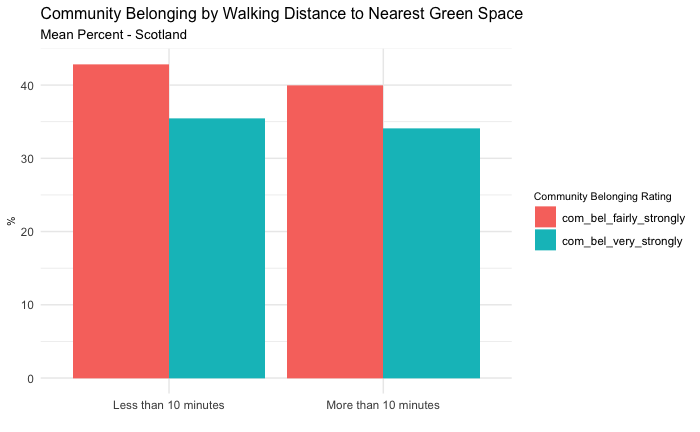

```r
graph_12_comm_extra_final
```

```r
neigh_comm_extra_pivot %>%
  filter(neighbourhood_rating %in% c("nr_very_good", "nr_fairly_good"))
```

| date_code | walking_distance_to_nearest_greenspace | neighbourhood_rating | nr_percent | community_belonging_rating | cb_percent |
| --- | --- | --- | --- | --- | --- |
| 2016 | More than 10 minutes | nr_very_good | 55 | com_bel_very_strongly | 35 |
| 2016 | More than 10 minutes | nr_very_good | 55 | com_bel_dont_know | 1 |
| 2016 | More than 10 minutes | nr_very_good | 55 | com_bel_not_at_all_strongly | 8 |
| 2016 | More than 10 minutes | nr_very_good | 55 | com_bel_fairly_strongly | 40 |
| 2016 | More than 10 minutes | nr_very_good | 55 | com_bel_not_very_strongly | 17 |
| 2016 | More than 10 minutes | nr_fairly_good | 38 | com_bel_very_strongly | 35 |
| 2016 | More than 10 minutes | nr_fairly_good | 38 | com_bel_dont_know | 1 |
| 2016 | More than 10 minutes | nr_fairly_good | 38 | com_bel_not_at_all_strongly | 8 |
| 2016 | More than 10 minutes | nr_fairly_good | 38 | com_bel_fairly_strongly | 40 |
| 2016 | More than 10 minutes | nr_fairly_good | 38 | com_bel_not_very_strongly | 17 |

[output cut: 130 more lines]

```r
remaining_graphs_data %>%
    filter(walking_distance_to_nearest_greenspace != "Don't Know",
         local_authority == "Scotland") %>%
    group_by(walking_distance_to_nearest_greenspace) %>%
    summarise(nr_very_good = mean(nr_very_good),
              nr_fairly_good = mean(nr_fairly_good),
              cb_very_strong = mean(com_bel_very_strongly),
              cb_fairly_strong = mean(com_bel_fairly_strongly))
```

| walking_distance_to_nearest_greenspace | nr_very_good | nr_fairly_good | cb_very_strong | cb_fairly_strong |
| --- | --- | --- | --- | --- |
| Less than 10 minutes | 57.14286 | 37.57143 | 35.42857 | 42.85714 |
| More than 10 minutes | 52.42857 | 39.85714 | 34.14286 | 40.00000 |

```r
#remaining_graphs_data %>%
# filter(walking_distance_to_nearest_greenspace != "Don't Know",
#         local_authority == "Scotland") %>%
#  ggplot() +
#  aes(x = walking_distance_to_nearest_greenspace, y = nr_very_good) +
#  geom_col()
```

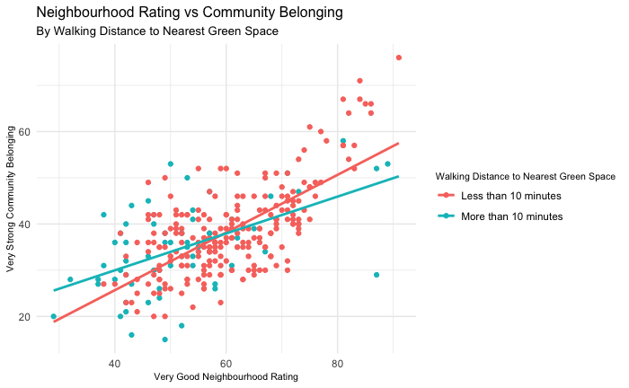

```r
graph_13_final <-
remaining_graphs_data %>%
  filter(walking_distance_to_nearest_greenspace != "Don't Know") %>%
  ggplot() +
  aes(x = nr_very_good, y = com_bel_very_strongly, color = walking_distance_to_nearest_greenspace) +
  geom_point() +
  geom_smooth(method = lm, se = FALSE, fullrange = TRUE) +
  theme_minimal() +
  labs(title = "Neighbourhood Rating vs Community Belonging",
          subtitle = "By Walking Distance to Nearest Green Space") +
  xlab("Very Good Neighbourhood Rating") +
  ylab("Very Strong Community Belonging") +
  labs(colour = "Walking Distance to Nearest Green Space") +
  theme(axis.title.y = element_text(size = 8),
        axis.title.x = element_text(size = 8),
        plot.title = element_text(size = 12),
        plot.subtitle = element_text(size = 10),
        legend.title = element_text(size = 8))

graph_13_final
```

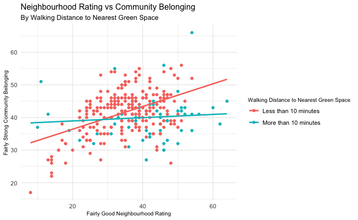

```r
graph_14_final <-
remaining_graphs_data  %>%
  filter(walking_distance_to_nearest_greenspace != "Don't Know") %>%
  ggplot() +
  aes(x = nr_fairly_good, y = com_bel_fairly_strongly, color = walking_distance_to_nearest_greenspace) +
  geom_point() +
  geom_smooth(method = lm, se = FALSE, fullrange = TRUE) +
  theme_minimal() +
  labs(title = "Neighbourhood Rating vs Community Belonging",
          subtitle = "By Walking Distance to Nearest Green Space") +
  xlab("Fairly Good Neighbourhood Rating") +
  ylab("Fairly Strong Community Belonging") +
  labs(colour = "Walking Distance to Nearest Green Space") +
  theme(axis.title.y = element_text(size = 8),
        axis.title.x = element_text(size = 8),
        plot.title = element_text(size = 12),
        plot.subtitle = element_text(size = 10),
        legend.title = element_text(size = 8))

  graph_14_final
```

Time to write all these graphs to png.